# Risk Factor Analysis

## Outcome Variable

**Outcome Variable:** pers_wast

## Predictor Variables

**Intervention Variable:** exclfeed3

**Adjustment Set:**

- arm
- sex
- W_mage
- meducyrs
- feducyrs
- hhwealth_quart
- hfoodsec
- W_mhtcm
- vagbrth
- W_gagebrth
- W_birthwt
- W_birthlen
- W_nrooms
- W_nchldlt5
- month
- brthmon
- W_parity
- impfloor
- impsan
- safeh20
- delta_W_mage
- delta_meducyrs
- delta_feducyrs
- delta_hhwealth_quart
- delta_hfoodsec
- delta_W_mhtcm
- delta_vagbrth
- delta_W_gagebrth
- delta_W_birthwt
- delta_W_birthlen
- delta_W_nrooms
- delta_W_nchldlt5
- delta_month
- delta_brthmon
- delta_W_parity
- delta_impfloor
- delta_impsan
- delta_safeh20

## Stratifying Variables

The analysis was stratified on these variable(s):

- agecat
- studyid
- country

## Data Summary

| agecat | studyid | country | exclfeed3 | pers_wast | n_cell | n |
| --- | --- | --- | --- | --- | --- | --- |
| 0-24 months | ki0047075b-MAL-ED | BANGLADESH | 0 | 0 | 63 | 244 |
| 0-24 months | ki0047075b-MAL-ED | BANGLADESH | 0 | 1 | 4 | 244 |
| 0-24 months | ki0047075b-MAL-ED | BANGLADESH | 1 | 0 | 169 | 244 |
| 0-24 months | ki0047075b-MAL-ED | BANGLADESH | 1 | 1 | 8 | 244 |
| 0-24 months | ki0047075b-MAL-ED | BRAZIL | 0 | 0 | 132 | 217 |
| 0-24 months | ki0047075b-MAL-ED | BRAZIL | 0 | 1 | 1 | 217 |
| 0-24 months | ki0047075b-MAL-ED | BRAZIL | 1 | 0 | 83 | 217 |
| 0-24 months | ki0047075b-MAL-ED | BRAZIL | 1 | 1 | 1 | 217 |
| 0-24 months | ki0047075b-MAL-ED | INDIA | 0 | 0 | 82 | 238 |
| 0-24 months | ki0047075b-MAL-ED | INDIA | 0 | 1 | 12 | 238 |
| 0-24 months | ki0047075b-MAL-ED | INDIA | 1 | 0 | 135 | 238 |
| 0-24 months | ki0047075b-MAL-ED | INDIA | 1 | 1 | 9 | 238 |
| 0-24 months | ki0047075b-MAL-ED | NEPAL | 0 | 0 | 147 | 235 |
| 0-24 months | ki0047075b-MAL-ED | NEPAL | 0 | 1 | 2 | 235 |
| 0-24 months | ki0047075b-MAL-ED | NEPAL | 1 | 0 | 84 | 235 |
| 0-24 months | ki0047075b-MAL-ED | NEPAL | 1 | 1 | 2 | 235 |
| 0-24 months | ki0047075b-MAL-ED | PERU | 0 | 0 | 212 | 281 |
| 0-24 months | ki0047075b-MAL-ED | PERU | 0 | 1 | 1 | 281 |
| 0-24 months | ki0047075b-MAL-ED | PERU | 1 | 0 | 68 | 281 |
| 0-24 months | ki0047075b-MAL-ED | PERU | 1 | 1 | 0 | 281 |
| 0-24 months | ki0047075b-MAL-ED | SOUTH AFRICA | 0 | 0 | 232 | 267 |
| 0-24 months | ki0047075b-MAL-ED | SOUTH AFRICA | 0 | 1 | 2 | 267 |
| 0-24 months | ki0047075b-MAL-ED | SOUTH AFRICA | 1 | 0 | 33 | 267 |
| 0-24 months | ki0047075b-MAL-ED | SOUTH AFRICA | 1 | 1 | 0 | 267 |
| 0-24 months | ki0047075b-MAL-ED | TANZANIA, UNITED REPUBLIC OF | 0 | 0 | 178 | 246 |
| 0-24 months | ki0047075b-MAL-ED | TANZANIA, UNITED REPUBLIC OF | 0 | 1 | 0 | 246 |
| 0-24 months | ki0047075b-MAL-ED | TANZANIA, UNITED REPUBLIC OF | 1 | 0 | 68 | 246 |
| 0-24 months | ki0047075b-MAL-ED | TANZANIA, UNITED REPUBLIC OF | 1 | 1 | 0 | 246 |
| 0-24 months | ki1000108-CMC-V-BCS-2002 | INDIA | 0 | 0 | 0 | 10 |
| 0-24 months | ki1000108-CMC-V-BCS-2002 | INDIA | 0 | 1 | 0 | 10 |

[output cut: 146 more lines]

The following strata were considered:

- agecat: 0-24 months, studyid: ki0047075b-MAL-ED, country: BANGLADESH
- agecat: 0-24 months, studyid: ki0047075b-MAL-ED, country: BRAZIL
- agecat: 0-24 months, studyid: ki0047075b-MAL-ED, country: INDIA
- agecat: 0-24 months, studyid: ki0047075b-MAL-ED, country: NEPAL
- agecat: 0-24 months, studyid: ki0047075b-MAL-ED, country: PERU
- agecat: 0-24 months, studyid: ki0047075b-MAL-ED, country: SOUTH AFRICA
- agecat: 0-24 months, studyid: ki0047075b-MAL-ED, country: TANZANIA, UNITED REPUBLIC OF
- agecat: 0-24 months, studyid: ki1000108-CMC-V-BCS-2002, country: INDIA
- agecat: 0-24 months, studyid: ki1000108-IRC, country: INDIA
- agecat: 0-24 months, studyid: ki1000109-EE, country: PAKISTAN
- agecat: 0-24 months, studyid: ki1000304b-SAS-CompFeed, country: INDIA
- agecat: 0-24 months, studyid: ki1017093b-PROVIDE, country: BANGLADESH
- agecat: 0-24 months, studyid: ki1101329-Keneba, country: GAMBIA
- agecat: 0-24 months, studyid: ki1113344-GMS-Nepal, country: NEPAL
- agecat: 0-24 months, studyid: kiGH5241-JiVitA-3, country: BANGLADESH
- agecat: 0-24 months, studyid: kiGH5241-JiVitA-4, country: BANGLADESH
- agecat: 0-6 months, studyid: ki0047075b-MAL-ED, country: BANGLADESH
- agecat: 0-6 months, studyid: ki0047075b-MAL-ED, country: BRAZIL
- agecat: 0-6 months, studyid: ki0047075b-MAL-ED, country: INDIA
- agecat: 0-6 months, studyid: ki0047075b-MAL-ED, country: NEPAL
- agecat: 0-6 months, studyid: ki0047075b-MAL-ED, country: PERU
- agecat: 0-6 months, studyid: ki0047075b-MAL-ED, country: SOUTH AFRICA
- agecat: 0-6 months, studyid: ki0047075b-MAL-ED, country: TANZANIA, UNITED REPUBLIC OF
- agecat: 0-6 months, studyid: ki1000108-CMC-V-BCS-2002, country: INDIA
- agecat: 0-6 months, studyid: ki1000108-IRC, country: INDIA
- agecat: 0-6 months, studyid: ki1000109-EE, country: PAKISTAN
- agecat: 0-6 months, studyid: ki1017093b-PROVIDE, country: BANGLADESH
- agecat: 0-6 months, studyid: ki1101329-Keneba, country: GAMBIA
- agecat: 0-6 months, studyid: ki1113344-GMS-Nepal, country: NEPAL
- agecat: 6-24 months, studyid: ki0047075b-MAL-ED, country: BANGLADESH
- agecat: 6-24 months, studyid: ki0047075b-MAL-ED, country: BRAZIL
- agecat: 6-24 months, studyid: ki0047075b-MAL-ED, country: INDIA
- agecat: 6-24 months, studyid: ki0047075b-MAL-ED, country: NEPAL
- agecat: 6-24 months, studyid: ki0047075b-MAL-ED, country: PERU
- agecat: 6-24 months, studyid: ki0047075b-MAL-ED, country: SOUTH AFRICA
- agecat: 6-24 months, studyid: ki0047075b-MAL-ED, country: TANZANIA, UNITED REPUBLIC OF
- agecat: 6-24 months, studyid: ki1000108-CMC-V-BCS-2002, country: INDIA
- agecat: 6-24 months, studyid: ki1000108-IRC, country: INDIA
- agecat: 6-24 months, studyid: ki1000109-EE, country: PAKISTAN
- agecat: 6-24 months, studyid: ki1000304b-SAS-CompFeed, country: INDIA
- agecat: 6-24 months, studyid: ki1017093b-PROVIDE, country: BANGLADESH
- agecat: 6-24 months, studyid: ki1101329-Keneba, country: GAMBIA
- agecat: 6-24 months, studyid: ki1113344-GMS-Nepal, country: NEPAL
- agecat: 6-24 months, studyid: kiGH5241-JiVitA-4, country: BANGLADESH

### Dropped Strata

Some strata were dropped due to rare outcomes:

- agecat: 0-24 months, studyid: ki0047075b-MAL-ED, country: BANGLADESH
- agecat: 0-24 months, studyid: ki0047075b-MAL-ED, country: BRAZIL
- agecat: 0-24 months, studyid: ki0047075b-MAL-ED, country: NEPAL
- agecat: 0-24 months, studyid: ki0047075b-MAL-ED, country: PERU
- agecat: 0-24 months, studyid: ki0047075b-MAL-ED, country: SOUTH AFRICA
- agecat: 0-24 months, studyid: ki0047075b-MAL-ED, country: TANZANIA, UNITED REPUBLIC OF
- agecat: 0-24 months, studyid: ki1000108-CMC-V-BCS-2002, country: INDIA
- agecat: 0-24 months, studyid: ki1000108-IRC, country: INDIA
- agecat: 0-24 months, studyid: ki1000304b-SAS-CompFeed, country: INDIA
- agecat: 0-24 months, studyid: kiGH5241-JiVitA-4, country: BANGLADESH
- agecat: 0-6 months, studyid: ki0047075b-MAL-ED, country: BANGLADESH
- agecat: 0-6 months, studyid: ki0047075b-MAL-ED, country: BRAZIL
- agecat: 0-6 months, studyid: ki0047075b-MAL-ED, country: NEPAL
- agecat: 0-6 months, studyid: ki0047075b-MAL-ED, country: PERU
- agecat: 0-6 months, studyid: ki0047075b-MAL-ED, country: SOUTH AFRICA
- agecat: 0-6 months, studyid: ki0047075b-MAL-ED, country: TANZANIA, UNITED REPUBLIC OF
- agecat: 0-6 months, studyid: ki1000108-CMC-V-BCS-2002, country: INDIA
- agecat: 0-6 months, studyid: ki1000108-IRC, country: INDIA
- agecat: 6-24 months, studyid: ki0047075b-MAL-ED, country: BANGLADESH
- agecat: 6-24 months, studyid: ki0047075b-MAL-ED, country: BRAZIL
- agecat: 6-24 months, studyid: ki0047075b-MAL-ED, country: NEPAL
- agecat: 6-24 months, studyid: ki0047075b-MAL-ED, country: PERU
- agecat: 6-24 months, studyid: ki0047075b-MAL-ED, country: SOUTH AFRICA
- agecat: 6-24 months, studyid: ki0047075b-MAL-ED, country: TANZANIA, UNITED REPUBLIC OF
- agecat: 6-24 months, studyid: ki1000108-CMC-V-BCS-2002, country: INDIA
- agecat: 6-24 months, studyid: ki1000108-IRC, country: INDIA
- agecat: 6-24 months, studyid: ki1000304b-SAS-CompFeed, country: INDIA
- agecat: 6-24 months, studyid: kiGH5241-JiVitA-4, country: BANGLADESH

## Methods Detail

We’re interested in the causal parameters $E[Y_a]$ for all values of $a \in \mathcal{A}$. These parameters represent the mean outcome if, possibly contrary to fact, we intervened to set all units to have $A=a$. Under the randomization and positivity assumptions, these are identified by the statistical parameters $\psi_a=E_W[E_{Y|A,W}(Y|A=a,W)]$. In addition, we’re interested in the mean of $Y$, $E[Y]$ under no intervention (the observed mean). We will estimate these parameters by using SuperLearner to fit the relevant likelihood factors – $E_{Y|A,W}(Y|A=a,W)$ and $p(A=a|W)$, and then updating our likelihood fit using a joint TMLE.

For unadjusted analyses ($W=\{\}$), initial likelihoods were estimated using Lrnr_glm to estimate the simple $E(Y|A)$ and Lrnr_mean to estimate $p(A)$. For adjusted analyses, a small library containing Lrnr_glmnet, Lrnr_xgboost, and Lrnr_mean was used.

Having estimated these parameters, we will then use the delta method to estimate relative risks and attributable risks relative to a prespecified baseline level of $A$.

# Results Detail

## Results Plots

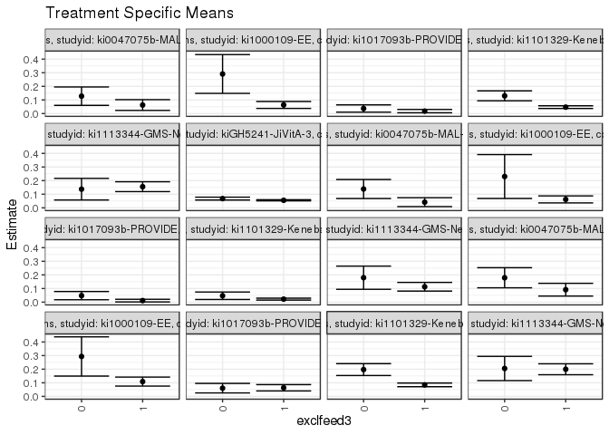

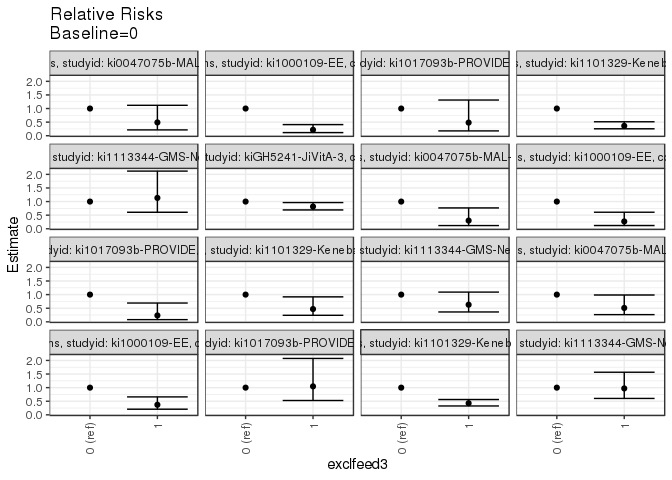

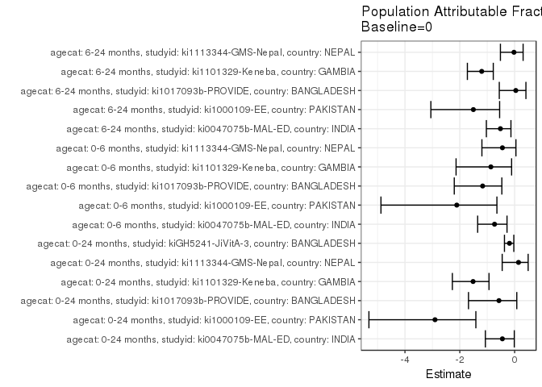

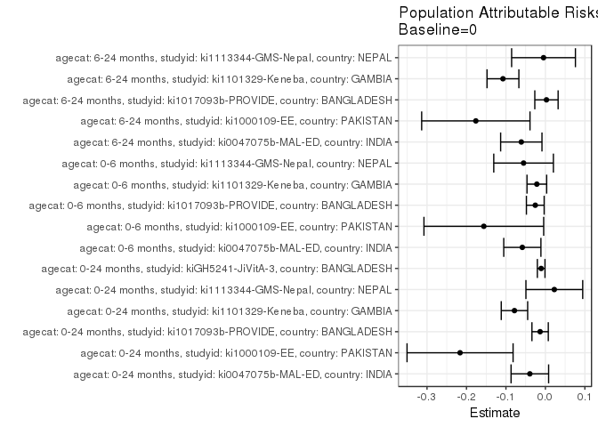

## Results Table

### Parameter: TSM

| agecat | studyid | country | intervention_level | baseline_level | estimate | ci_lower | ci_upper |
| --- | --- | --- | --- | --- | --- | --- | --- |
| 0-24 months | ki0047075b-MAL-ED | INDIA | 0 | NA | 0.1276596 | 0.0600562 | 0.1952629 |
| 0-24 months | ki0047075b-MAL-ED | INDIA | 1 | NA | 0.0625000 | 0.0228807 | 0.1021193 |
| 0-24 months | ki1000109-EE | PAKISTAN | 0 | NA | 0.2907373 | 0.1482575 | 0.4332172 |
| 0-24 months | ki1000109-EE | PAKISTAN | 1 | NA | 0.0631135 | 0.0376886 | 0.0885384 |
| 0-24 months | ki1017093b-PROVIDE | BANGLADESH | 0 | NA | 0.0368421 | 0.0100361 | 0.0636481 |
| 0-24 months | ki1017093b-PROVIDE | BANGLADESH | 1 | NA | 0.0177778 | 0.0055591 | 0.0299965 |
| 0-24 months | ki1101329-Keneba | GAMBIA | 0 | NA | 0.1301671 | 0.0936866 | 0.1666477 |
| 0-24 months | ki1101329-Keneba | GAMBIA | 1 | NA | 0.0470940 | 0.0371721 | 0.0570158 |
| 0-24 months | ki1113344-GMS-Nepal | NEPAL | 0 | NA | 0.1369832 | 0.0575101 | 0.2164563 |
| 0-24 months | ki1113344-GMS-Nepal | NEPAL | 1 | NA | 0.1553383 | 0.1191981 | 0.1914784 |
| 0-24 months | kiGH5241-JiVitA-3 | BANGLADESH | 0 | NA | 0.0677716 | 0.0572049 | 0.0783383 |
| 0-24 months | kiGH5241-JiVitA-3 | BANGLADESH | 1 | NA | 0.0553427 | 0.0511394 | 0.0595459 |
| 0-6 months | ki0047075b-MAL-ED | INDIA | 0 | NA | 0.1382979 | 0.0683644 | 0.2082313 |
| 0-6 months | ki0047075b-MAL-ED | INDIA | 1 | NA | 0.0416667 | 0.0089602 | 0.0743732 |
| 0-6 months | ki1000109-EE | PAKISTAN | 0 | NA | 0.2300476 | 0.0687640 | 0.3913313 |
| 0-6 months | ki1000109-EE | PAKISTAN | 1 | NA | 0.0619660 | 0.0362699 | 0.0876621 |
| 0-6 months | ki1017093b-PROVIDE | BANGLADESH | 0 | NA | 0.0476190 | 0.0172344 | 0.0780037 |
| 0-6 months | ki1017093b-PROVIDE | BANGLADESH | 1 | NA | 0.0111607 | 0.0014252 | 0.0208962 |
| 0-6 months | ki1101329-Keneba | GAMBIA | 0 | NA | 0.0468017 | 0.0193567 | 0.0742466 |
| 0-6 months | ki1101329-Keneba | GAMBIA | 1 | NA | 0.0219674 | 0.0148059 | 0.0291290 |
| 0-6 months | ki1113344-GMS-Nepal | NEPAL | 0 | NA | 0.1794872 | 0.0942294 | 0.2647449 |
| 0-6 months | ki1113344-GMS-Nepal | NEPAL | 1 | NA | 0.1128609 | 0.0810536 | 0.1446682 |
| 6-24 months | ki0047075b-MAL-ED | INDIA | 0 | NA | 0.1789694 | 0.1051106 | 0.2528282 |
| 6-24 months | ki0047075b-MAL-ED | INDIA | 1 | NA | 0.0912536 | 0.0443363 | 0.1381709 |
| 6-24 months | ki1000109-EE | PAKISTAN | 0 | NA | 0.2934758 | 0.1492673 | 0.4376842 |
| 6-24 months | ki1000109-EE | PAKISTAN | 1 | NA | 0.1088187 | 0.0757706 | 0.1418668 |
| 6-24 months | ki1017093b-PROVIDE | BANGLADESH | 0 | NA | 0.0605423 | 0.0255468 | 0.0955378 |
| 6-24 months | ki1017093b-PROVIDE | BANGLADESH | 1 | NA | 0.0633736 | 0.0401806 | 0.0865665 |
| 6-24 months | ki1101329-Keneba | GAMBIA | 0 | NA | 0.1971747 | 0.1535761 | 0.2407733 |
| 6-24 months | ki1101329-Keneba | GAMBIA | 1 | NA | 0.0845706 | 0.0710140 | 0.0981271 |
| 6-24 months | ki1113344-GMS-Nepal | NEPAL | 0 | NA | 0.2051994 | 0.1162698 | 0.2941291 |
| 6-24 months | ki1113344-GMS-Nepal | NEPAL | 1 | NA | 0.1994607 | 0.1593145 | 0.2396069 |

### Parameter: E(Y)

| agecat | studyid | country | intervention_level | baseline_level | estimate | ci_lower | ci_upper |
| --- | --- | --- | --- | --- | --- | --- | --- |
| 0-24 months | ki0047075b-MAL-ED | INDIA | NA | NA | 0.0882353 | 0.0521245 | 0.1243460 |
| 0-24 months | ki1000109-EE | PAKISTAN | NA | NA | 0.0744681 | 0.0478968 | 0.1010394 |
| 0-24 months | ki1017093b-PROVIDE | BANGLADESH | NA | NA | 0.0234375 | 0.0117074 | 0.0351676 |
| 0-24 months | ki1101329-Keneba | GAMBIA | NA | NA | 0.0517418 | 0.0419129 | 0.0615707 |
| 0-24 months | ki1113344-GMS-Nepal | NEPAL | NA | NA | 0.1595745 | 0.1264314 | 0.1927176 |
| 0-24 months | kiGH5241-JiVitA-3 | BANGLADESH | NA | NA | 0.0570377 | 0.0528781 | 0.0611972 |
| 0-6 months | ki0047075b-MAL-ED | INDIA | NA | NA | 0.0798319 | 0.0453258 | 0.1143380 |
| 0-6 months | ki1000109-EE | PAKISTAN | NA | NA | 0.0739726 | 0.0470855 | 0.1008598 |
| 0-6 months | ki1017093b-PROVIDE | BANGLADESH | NA | NA | 0.0219780 | 0.0105837 | 0.0333723 |
| 0-6 months | ki1101329-Keneba | GAMBIA | NA | NA | 0.0250818 | 0.0179232 | 0.0322404 |
| 0-6 months | ki1113344-GMS-Nepal | NEPAL | NA | NA | 0.1241830 | 0.0939798 | 0.1543862 |
| 6-24 months | ki0047075b-MAL-ED | INDIA | NA | NA | 0.1179039 | 0.0760436 | 0.1597643 |
| 6-24 months | ki1000109-EE | PAKISTAN | NA | NA | 0.1171662 | 0.0842168 | 0.1501157 |
| 6-24 months | ki1017093b-PROVIDE | BANGLADESH | NA | NA | 0.0632280 | 0.0437545 | 0.0827015 |
| 6-24 months | ki1101329-Keneba | GAMBIA | NA | NA | 0.0895938 | 0.0763853 | 0.1028022 |
| 6-24 months | ki1113344-GMS-Nepal | NEPAL | NA | NA | 0.2004357 | 0.1637726 | 0.2370989 |

### Parameter: RR

| agecat | studyid | country | intervention_level | baseline_level | estimate | ci_lower | ci_upper |
| --- | --- | --- | --- | --- | --- | --- | --- |
| 0-24 months | ki0047075b-MAL-ED | INDIA | 0 | 0 | 1.0000000 | 1.0000000 | 1.0000000 |
| 0-24 months | ki0047075b-MAL-ED | INDIA | 1 | 0 | 0.4895833 | 0.2143384 | 1.1182869 |
| 0-24 months | ki1000109-EE | PAKISTAN | 0 | 0 | 1.0000000 | 1.0000000 | 1.0000000 |
| 0-24 months | ki1000109-EE | PAKISTAN | 1 | 0 | 0.2170808 | 0.1150719 | 0.4095187 |
| 0-24 months | ki1017093b-PROVIDE | BANGLADESH | 0 | 0 | 1.0000000 | 1.0000000 | 1.0000000 |
| 0-24 months | ki1017093b-PROVIDE | BANGLADESH | 1 | 0 | 0.4825397 | 0.1773592 | 1.3128415 |
| 0-24 months | ki1101329-Keneba | GAMBIA | 0 | 0 | 1.0000000 | 1.0000000 | 1.0000000 |
| 0-24 months | ki1101329-Keneba | GAMBIA | 1 | 0 | 0.3617963 | 0.2548837 | 0.5135541 |
| 0-24 months | ki1113344-GMS-Nepal | NEPAL | 0 | 0 | 1.0000000 | 1.0000000 | 1.0000000 |
| 0-24 months | ki1113344-GMS-Nepal | NEPAL | 1 | 0 | 1.1339950 | 0.6068181 | 2.1191600 |
| 0-24 months | kiGH5241-JiVitA-3 | BANGLADESH | 0 | 0 | 1.0000000 | 1.0000000 | 1.0000000 |
| 0-24 months | kiGH5241-JiVitA-3 | BANGLADESH | 1 | 0 | 0.8166055 | 0.6926687 | 0.9627178 |
| 0-6 months | ki0047075b-MAL-ED | INDIA | 0 | 0 | 1.0000000 | 1.0000000 | 1.0000000 |
| 0-6 months | ki0047075b-MAL-ED | INDIA | 1 | 0 | 0.3012821 | 0.1184289 | 0.7664590 |
| 0-6 months | ki1000109-EE | PAKISTAN | 0 | 0 | 1.0000000 | 1.0000000 | 1.0000000 |
| 0-6 months | ki1000109-EE | PAKISTAN | 1 | 0 | 0.2693614 | 0.1193205 | 0.6080730 |
| 0-6 months | ki1017093b-PROVIDE | BANGLADESH | 0 | 0 | 1.0000000 | 1.0000000 | 1.0000000 |
| 0-6 months | ki1017093b-PROVIDE | BANGLADESH | 1 | 0 | 0.2343750 | 0.0795318 | 0.6906879 |
| 0-6 months | ki1101329-Keneba | GAMBIA | 0 | 0 | 1.0000000 | 1.0000000 | 1.0000000 |
| 0-6 months | ki1101329-Keneba | GAMBIA | 1 | 0 | 0.4693732 | 0.2402288 | 0.9170891 |
| 0-6 months | ki1113344-GMS-Nepal | NEPAL | 0 | 0 | 1.0000000 | 1.0000000 | 1.0000000 |
| 0-6 months | ki1113344-GMS-Nepal | NEPAL | 1 | 0 | 0.6287964 | 0.3619428 | 1.0923960 |
| 6-24 months | ki0047075b-MAL-ED | INDIA | 0 | 0 | 1.0000000 | 1.0000000 | 1.0000000 |
| 6-24 months | ki0047075b-MAL-ED | INDIA | 1 | 0 | 0.5098838 | 0.2636866 | 0.9859489 |
| 6-24 months | ki1000109-EE | PAKISTAN | 0 | 0 | 1.0000000 | 1.0000000 | 1.0000000 |
| 6-24 months | ki1000109-EE | PAKISTAN | 1 | 0 | 0.3707929 | 0.2081403 | 0.6605513 |
| 6-24 months | ki1017093b-PROVIDE | BANGLADESH | 0 | 0 | 1.0000000 | 1.0000000 | 1.0000000 |
| 6-24 months | ki1017093b-PROVIDE | BANGLADESH | 1 | 0 | 1.0467647 | 0.5282352 | 2.0742963 |
| 6-24 months | ki1101329-Keneba | GAMBIA | 0 | 0 | 1.0000000 | 1.0000000 | 1.0000000 |
| 6-24 months | ki1101329-Keneba | GAMBIA | 1 | 0 | 0.4289121 | 0.3264811 | 0.5634799 |
| 6-24 months | ki1113344-GMS-Nepal | NEPAL | 0 | 0 | 1.0000000 | 1.0000000 | 1.0000000 |
| 6-24 months | ki1113344-GMS-Nepal | NEPAL | 1 | 0 | 0.9720334 | 0.6033506 | 1.5660032 |

### Parameter: PAR

| agecat | studyid | country | intervention_level | baseline_level | estimate | ci_lower | ci_upper |
| --- | --- | --- | --- | --- | --- | --- | --- |
| 0-24 months | ki0047075b-MAL-ED | INDIA | 0 | NA | -0.0394243 | -0.0870070 | 0.0081584 |
| 0-24 months | ki1000109-EE | PAKISTAN | 0 | NA | -0.2162693 | -0.3506420 | -0.0818965 |
| 0-24 months | ki1017093b-PROVIDE | BANGLADESH | 0 | NA | -0.0134046 | -0.0341293 | 0.0073201 |
| 0-24 months | ki1101329-Keneba | GAMBIA | 0 | NA | -0.0784253 | -0.1118943 | -0.0449564 |
| 0-24 months | ki1113344-GMS-Nepal | NEPAL | 0 | NA | 0.0225912 | -0.0493671 | 0.0945496 |
| 0-24 months | kiGH5241-JiVitA-3 | BANGLADESH | 0 | NA | -0.0107339 | -0.0204035 | -0.0010643 |
| 0-6 months | ki0047075b-MAL-ED | INDIA | 0 | NA | -0.0584659 | -0.1055629 | -0.0113690 |
| 0-6 months | ki1000109-EE | PAKISTAN | 0 | NA | -0.1560750 | -0.3077688 | -0.0043812 |
| 0-6 months | ki1017093b-PROVIDE | BANGLADESH | 0 | NA | -0.0256410 | -0.0481179 | -0.0031642 |
| 0-6 months | ki1101329-Keneba | GAMBIA | 0 | NA | -0.0217199 | -0.0466515 | 0.0032118 |
| 0-6 months | ki1113344-GMS-Nepal | NEPAL | 0 | NA | -0.0553042 | -0.1308730 | 0.0202646 |
| 6-24 months | ki0047075b-MAL-ED | INDIA | 0 | NA | -0.0610655 | -0.1134334 | -0.0086975 |
| 6-24 months | ki1000109-EE | PAKISTAN | 0 | NA | -0.1763096 | -0.3135749 | -0.0390442 |
| 6-24 months | ki1017093b-PROVIDE | BANGLADESH | 0 | NA | 0.0026856 | -0.0268526 | 0.0322239 |
| 6-24 months | ki1101329-Keneba | GAMBIA | 0 | NA | -0.1075809 | -0.1479395 | -0.0672223 |
| 6-24 months | ki1113344-GMS-Nepal | NEPAL | 0 | NA | -0.0047637 | -0.0855947 | 0.0760672 |

### Parameter: PAF

| agecat | studyid | country | intervention_level | baseline_level | estimate | ci_lower | ci_upper |
| --- | --- | --- | --- | --- | --- | --- | --- |
| 0-24 months | ki0047075b-MAL-ED | INDIA | 0 | NA | -0.4468085 | -1.0674801 | -0.0124668 |
| 0-24 months | ki1000109-EE | PAKISTAN | 0 | NA | -2.9041872 | -5.3147182 | -1.4138334 |
| 0-24 months | ki1017093b-PROVIDE | BANGLADESH | 0 | NA | -0.5719298 | -1.6828697 | 0.0789850 |
| 0-24 months | ki1101329-Keneba | GAMBIA | 0 | NA | -1.5157050 | -2.2714957 | -0.9345194 |
| 0-24 months | ki1113344-GMS-Nepal | NEPAL | 0 | NA | 0.1415718 | -0.4536159 | 0.4930580 |
| 0-24 months | kiGH5241-JiVitA-3 | BANGLADESH | 0 | NA | -0.1881902 | -0.3708834 | -0.0298440 |
| 0-6 months | ki0047075b-MAL-ED | INDIA | 0 | NA | -0.7323628 | -1.3486031 | -0.2778152 |
| 0-6 months | ki1000109-EE | PAKISTAN | 0 | NA | -2.1099032 | -4.8756458 | -0.6460315 |
| 0-6 months | ki1017093b-PROVIDE | BANGLADESH | 0 | NA | -1.1666667 | -2.2015803 | -0.4662898 |
| 0-6 months | ki1101329-Keneba | GAMBIA | 0 | NA | -0.8659619 | -2.1360063 | -0.1102701 |
| 0-6 months | ki1113344-GMS-Nepal | NEPAL | 0 | NA | -0.4453441 | -1.1933264 | 0.0475564 |
| 6-24 months | ki0047075b-MAL-ED | INDIA | 0 | NA | -0.5179255 | -1.0309187 | -0.1345102 |
| 6-24 months | ki1000109-EE | PAKISTAN | 0 | NA | -1.5047816 | -3.0552056 | -0.5471301 |
| 6-24 months | ki1017093b-PROVIDE | BANGLADESH | 0 | NA | 0.0424755 | -0.5594931 | 0.4120826 |
| 6-24 months | ki1101329-Keneba | GAMBIA | 0 | NA | -1.2007631 | -1.7230872 | -0.7786277 |
| 6-24 months | ki1113344-GMS-Nepal | NEPAL | 0 | NA | -0.0237668 | -0.5180152 | 0.3095600 |